# Supplemental Analyses

# Intervention checks

## How much did they take Jen’s perspective?

```r
pt_check_df <- clean_data_bfi %>%
  select(sub_id, analog_condition, intervention_check1, intervention_check2, intervention_check3) %>%
  unique() %>%
  mutate(intervention_check1 = as.numeric(dplyr::recode(intervention_check1, #how much did you take Jen's perspective
                                             `Completely` = "4",
                                             `Moderately` = "3",
                                             `Slightly` = "2",
                                             `Not at all` = "1")),
         intervention_check2 = as.numeric(dplyr::recode(intervention_check2, # How misunderstood is Jen
                                             `Always` = "4",
                                             `Slightly` = "3",
                                             `Rarely` = "2",
                                             `Not at all` = "1")))

pt_check_df %>%
  group_by(analog_condition) %>%
  mutate(mean = mean(intervention_check1),
         sd = sd(intervention_check1)) %>%
  select(analog_condition, mean, sd) %>%
  unique()
```

```
## # A tibble: 2 × 3
## # Groups:   analog_condition [2]
##   analog_condition  mean    sd
##   <fct>            <dbl> <dbl>
## 1 analog            2.70  1.09
## 2 control           2.64  1.06
```

```r
int_check1_res <- aov(intervention_check1 ~ analog_condition, data = pt_check_df)
anova(int_check1_res)
```

```
## Analysis of Variance Table
##
## Response: intervention_check1
##                   Df Sum Sq Mean Sq F value Pr(>F)
## analog_condition   1   0.38 0.37744  0.3277 0.5673
## Residuals        422 486.07 1.15182
```

How much they reported taking her perspective was not significantly different

## How misunderstood was Jen?

```r
pt_check_df %>%
  group_by(analog_condition) %>%
  mutate(mean = mean(intervention_check2),
         sd = sd(intervention_check2)) %>%
  select(analog_condition, mean, sd) %>%
  unique()
```

```
## # A tibble: 2 × 3
## # Groups:   analog_condition [2]
##   analog_condition  mean    sd
##   <fct>            <dbl> <dbl>
## 1 analog            3.35 0.724
## 2 control           3.2  0.831
```

```r
int_check2_res <- aov(intervention_check2 ~ analog_condition, data = pt_check_df)
anova(int_check2_res)
```

```
## Analysis of Variance Table
##
## Response: intervention_check2
##                   Df Sum Sq Mean Sq F value  Pr(>F)
## analog_condition   1   2.32 2.31975  3.8018 0.05186 .
## Residuals        422 257.49 0.61016
## ---
## Signif. codes:  0 '***' 0.001 '**' 0.01 '*' 0.05 '.' 0.1 ' ' 1
```

# Checking mean/sd of bfi_self responses per item

```r
bfi_wide_self <- clean_data_bfi %>%
  select(sub_id, bfi_number, bfi_self) %>%
  unique() %>%
  pivot_wider(names_from = bfi_number, values_from = bfi_self) %>%
  select(sub_id, "1":"19") %>%
  unique()

psych::describe(bfi_wide_self)
```

```
##         vars   n   mean     sd median trimmed    mad min max range  skew
## sub_id*    1 424 212.50 122.54  212.5  212.50 157.16   1 424   423  0.00
## 1          2 424   2.40   1.26    2.0    2.26   1.48   1   5     4  0.69
## 2          3 424   4.23   0.94    4.0    4.40   1.48   1   5     4 -1.45
## 3          4 424   3.45   1.40    4.0    3.56   1.48   1   5     4 -0.41
## 4          5 424   3.51   1.43    4.0    3.64   1.48   1   5     4 -0.55
## 5          6 424   4.27   0.94    5.0    4.43   0.00   1   5     4 -1.17
## 6          7 424   2.75   1.24    3.0    2.72   1.48   1   5     4  0.05
## 7          8 424   3.71   1.20    4.0    3.78   1.48   1   5     4 -0.47
## 8          9 424   2.94   1.39    3.0    2.93   1.48   1   5     4  0.16
## 9         10 424   2.98   1.46    3.0    2.97   1.48   1   5     4 -0.04
## 10        11 424   4.03   1.09    4.0    4.19   1.48   1   5     4 -0.96
## 11        12 424   2.90   1.21    3.0    2.87   1.48   1   5     4  0.10
## 12        13 424   3.32   1.20    4.0    3.39   1.48   1   5     4 -0.40
## 13        14 424   4.17   0.91    4.0    4.31   1.48   2   5     3 -0.98
```

[output cut: 27 more lines]

# Variance around threat composite by threat condition

```r
clean_data_bfi %>%
  select(sub_id, itt_comp_gmc, target_condition) %>%
  group_by(target_condition) %>%
  mutate(mean = mean(itt_comp_gmc),
         sd = sd(itt_comp_gmc)) %>%
  select(target_condition, mean, sd) %>%
  unique()
```

```
## # A tibble: 3 × 3
## # Groups:   target_condition [3]
##   target_condition   mean    sd
##   <fct>             <dbl> <dbl>
## 1 CONTROL          -0.994 0.779
## 2 LOSS              0.698 0.699
## 3 WARM              0.418 0.811
```

## Control condition only

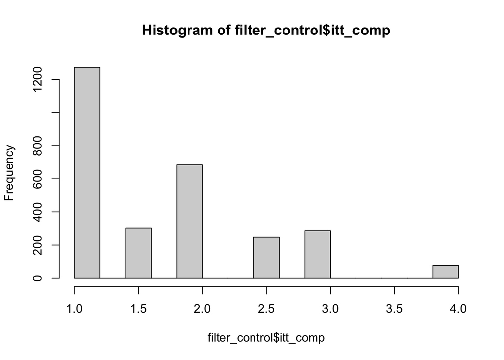

```r
filter_control <- clean_data_bfi %>%
  filter(target_condition == "CONTROL")

hist(filter_control$itt_comp)
```

## Warm condition only

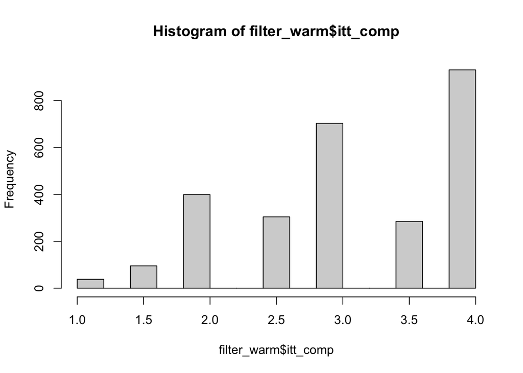

```r
filter_warm <- clean_data_bfi %>%
  filter(target_condition == "WARM")

hist(filter_warm$itt_comp)
```

## Political loss condition only

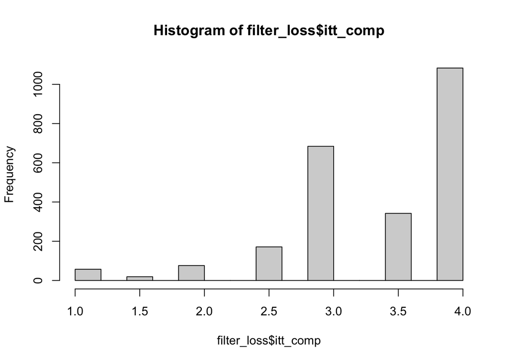

```r
filter_loss <- clean_data_bfi %>%
  filter(target_condition == "LOSS")

hist(filter_loss$itt_comp)
```

# Testing effect of centering

## Only composite

### person mean centered

```r
data_bfi <- clean_data_bfi %>%
  select(sub_id, bfi_number, bfi_targ_pmc, bfi_self_pmc, itt_comp_gmc,
         target_condition, bfi_targ, bfi_self, bfi_stereo, bfi_stereo_pmc,
         bfi_targ_gmc, bfi_self_gmc, bfi_stereo_gmc) %>%
  unique() %>%
  na.omit()

bfi_pmc1 <- lmer(bfi_targ_pmc ~ bfi_self_pmc*itt_comp_gmc +
                     (bfi_self_pmc | sub_id), data = data_bfi)
summary(bfi_pmc1)
```

```
## Linear mixed model fit by REML ['lmerMod']
## Formula: bfi_targ_pmc ~ bfi_self_pmc * itt_comp_gmc + (bfi_self_pmc |
##     sub_id)
##    Data: data_bfi
##
## REML criterion at convergence: 23334.3
##
## Scaled residuals:
##     Min      1Q  Median      3Q     Max
## -3.7620 -0.6103 -0.0189  0.6510  3.5515
##
## Random effects:
##  Groups   Name         Variance Std.Dev. Corr
##  sub_id   (Intercept)  0.15039  0.3878
##           bfi_self_pmc 0.05783  0.2405   0.64
##  Residual              0.94067  0.9699
## Number of obs: 8056, groups:  sub_id, 424
##
## Fixed effects:
##                            Estimate Std. Error t value
## (Intercept)                0.010483   0.021846   0.480
## bfi_self_pmc               0.005026   0.014560   0.345
## itt_comp_gmc              -0.293358   0.020406 -14.376
## bfi_self_pmc:itt_comp_gmc -0.133187   0.013539  -9.837
##
## Correlation of Fixed Effects:
##             (Intr) bf_sl_ itt_c_
## bfi_slf_pmc  0.446
## itt_cmp_gmc  0.000  0.000
## bf_slf_p:__  0.000 -0.015  0.437
```

```r
tab_model(bfi_pmc1)
```

|  | bfi_targ_pmc |  |  |
| --- | --- | --- | --- |
| Predictors | Estimates | CI | p |
| (Intercept) | 0.01 | -0.03 – 0.05 | 0.631 |
| bfi self pmc | 0.01 | -0.02 – 0.03 | 0.730 |
| itt comp gmc | -0.29 | -0.33 – -0.25 | **<0.001** |
| bfi self pmc * itt comp gmc | -0.13 | -0.16 – -0.11 | **<0.001** |
| Random Effects |  |  |  |
| σ<sup>2</sup> | 0.94 |  |  |
| τ<sub>00</sub> <sub>sub_id</sub> | 0.15 |  |  |
| τ<sub>11</sub> <sub>sub_id.bfi_self_pmc</sub> | 0.06 |  |  |
| ρ<sub>01</sub> <sub>sub_id</sub> | 0.64 |  |  |
| ICC | 0.21 |  |  |
| N <sub>sub_id</sub> | 424 |  |  |
| Observations | 8056 |  |  |
| Marginal R<sup>2</sup> / Conditional R<sup>2</sup> | 0.105 / 0.294 |  |  |

### Grand mean centered

```r
bfi_gmc1 <- lmer(bfi_targ ~ bfi_self_gmc*itt_comp_gmc +
                     (bfi_self_gmc | sub_id), data = data_bfi)
summary(bfi_gmc1)
```

```
## Linear mixed model fit by REML ['lmerMod']
## Formula: bfi_targ ~ bfi_self_gmc * itt_comp_gmc + (bfi_self_gmc | sub_id)
##    Data: data_bfi
##
## REML criterion at convergence: 23334.3
##
## Scaled residuals:
##     Min      1Q  Median      3Q     Max
## -3.7620 -0.6103 -0.0189  0.6510  3.5515
##
## Random effects:
##  Groups   Name         Variance Std.Dev. Corr
##  sub_id   (Intercept)  0.15039  0.3878
##           bfi_self_gmc 0.05783  0.2405   0.64
##  Residual              0.94067  0.9699
## Number of obs: 8056, groups:  sub_id, 424
##
## Fixed effects:
##                            Estimate Std. Error t value
## (Intercept)                3.173229   0.021846 145.254
## bfi_self_gmc               0.005026   0.014560   0.345
## itt_comp_gmc              -0.293358   0.020406 -14.376
## bfi_self_gmc:itt_comp_gmc -0.133187   0.013539  -9.837
##
## Correlation of Fixed Effects:
##             (Intr) bf_sl_ itt_c_
## bfi_slf_gmc  0.446
## itt_cmp_gmc  0.000  0.000
## bf_slf_g:__  0.000 -0.015  0.437
```

```r
tab_model(bfi_gmc1)
```

|  | bfi_targ |  |  |
| --- | --- | --- | --- |
| Predictors | Estimates | CI | p |
| (Intercept) | 3.17 | 3.13 – 3.22 | **<0.001** |
| bfi self gmc | 0.01 | -0.02 – 0.03 | 0.730 |
| itt comp gmc | -0.29 | -0.33 – -0.25 | **<0.001** |
| bfi self gmc * itt comp gmc | -0.13 | -0.16 – -0.11 | **<0.001** |
| Random Effects |  |  |  |
| σ<sup>2</sup> | 0.94 |  |  |
| τ<sub>00</sub> <sub>sub_id</sub> | 0.15 |  |  |
| τ<sub>11</sub> <sub>sub_id.bfi_self_gmc</sub> | 0.06 |  |  |
| ρ<sub>01</sub> <sub>sub_id</sub> | 0.64 |  |  |
| ICC | 0.21 |  |  |
| N <sub>sub_id</sub> | 424 |  |  |
| Observations | 8056 |  |  |
| Marginal R<sup>2</sup> / Conditional R<sup>2</sup> | 0.105 / 0.294 |  |  |

# Exploring different personality traits and counter-projection

## Extraversion

```r
# Getting data for extraversion model
extra_mod_data <- clean_data_bfi %>%
  select(sub_id, bfi_number, bfi_targ_pmc, bfi_self_pmc, bfi_stereo_pmc, itt_comp_gmc, target_condition, bfi_targ) %>%
  filter(bfi_number == 1 | bfi_number == 6 | bfi_number == 11) %>%
  unique() %>%
  na.omit()

extra_mod_nostereo <- lmer(bfi_targ_pmc ~ bfi_self_pmc*itt_comp_gmc +
                     (bfi_self_pmc | sub_id), data = extra_mod_data) # singular with correlation betwwen intercept and random slope equal to 0 and random slope very close to o
summary(extra_mod_nostereo)
```

```
## Linear mixed model fit by REML ['lmerMod']
## Formula: bfi_targ_pmc ~ bfi_self_pmc * itt_comp_gmc + (bfi_self_pmc |
##     sub_id)
##    Data: extra_mod_data
##
## REML criterion at convergence: 3548.9
##
## Scaled residuals:
##     Min      1Q  Median      3Q     Max
## -2.9472 -0.5233  0.1262  0.6221  2.5391
##
## Random effects:
##  Groups   Name         Variance Std.Dev. Corr
##  sub_id   (Intercept)  0.243661 0.49362
##           bfi_self_pmc 0.003185 0.05644  1.00
##  Residual              0.774614 0.88012
## Number of obs: 1272, groups:  sub_id, 424
##
## Fixed effects:
##                             Estimate Std. Error t value
## (Intercept)                0.3592535  0.0397162   9.046
## bfi_self_pmc              -0.0271641  0.0233217  -1.165
## itt_comp_gmc              -0.0006332  0.0360556  -0.018
## bfi_self_pmc:itt_comp_gmc -0.0772780  0.0212681  -3.634
##
## Correlation of Fixed Effects:
##             (Intr) bf_sl_ itt_c_
## bfi_slf_pmc  0.564
## itt_cmp_gmc  0.014  0.006
## bf_slf_p:__  0.003 -0.042  0.521
## optimizer (nloptwrap) convergence code: 0 (OK)
## boundary (singular) fit: see help('isSingular')
```

```r
tab_model(extra_mod_nostereo)
```

|  | bfi_targ_pmc |  |  |
| --- | --- | --- | --- |
| Predictors | Estimates | CI | p |
| (Intercept) | 0.36 | 0.28 – 0.44 | **<0.001** |
| bfi self pmc | -0.03 | -0.07 – 0.02 | 0.244 |
| itt comp gmc | -0.00 | -0.07 – 0.07 | 0.986 |
| bfi self pmc * itt comp gmc | -0.08 | -0.12 – -0.04 | **<0.001** |
| Random Effects |  |  |  |
| σ<sup>2</sup> | 0.77 |  |  |
| τ<sub>00</sub> <sub>sub_id</sub> | 0.24 |  |  |
| τ<sub>11</sub> <sub>sub_id.bfi_self_pmc</sub> | 0.00 |  |  |
| ρ<sub>01</sub> <sub>sub_id</sub> | 1.00 |  |  |
| ICC | 0.21 |  |  |
| N <sub>sub_id</sub> | 424 |  |  |
| Observations | 1272 |  |  |
| Marginal R<sup>2</sup> / Conditional R<sup>2</sup> | 0.017 / 0.223 |  |  |

### Simple slopes

```r
threat_levels = list(itt_comp_gmc = c(-1.07, 0.0, 1.07))
extra_ss <- emtrends(extra_mod_nostereo, ~ itt_comp_gmc,
                              var ="bfi_self_pmc",
                              at = threat_levels)

extra_ss
```

```
##  itt_comp_gmc bfi_self_pmc.trend     SE  df lower.CL upper.CL
##         -1.07             0.0555 0.0335 308  -0.0103   0.1214
##          0.00            -0.0272 0.0234 309  -0.0733   0.0190
##          1.07            -0.1099 0.0321 279  -0.1729  -0.0468
##
## Degrees-of-freedom method: kenward-roger
## Confidence level used: 0.95
```

```r
test(extra_ss)
```

```
##  itt_comp_gmc bfi_self_pmc.trend     SE  df t.ratio p.value
##         -1.07             0.0555 0.0335 308   1.660  0.0980
##          0.00            -0.0272 0.0234 309  -1.159  0.2475
##          1.07            -0.1099 0.0321 279  -3.427  0.0007
##
## Degrees-of-freedom method: kenward-roger
```

```r
pairs(extra_ss)
```

```
##  contrast       estimate     SE  df t.ratio p.value
##  (-1.07) - 0      0.0827 0.0229 279   3.614  0.0010
##  (-1.07) - 1.07   0.1654 0.0458 279   3.614  0.0010
##  0 - 1.07         0.0827 0.0229 279   3.614  0.0010
##
## Degrees-of-freedom method: kenward-roger
## P value adjustment: tukey method for comparing a family of 3 estimates
```

### With stereotyping

```r
extra_mod_stereo <- lmer(bfi_targ_pmc ~ bfi_self_pmc*itt_comp_gmc*bfi_stereo_pmc +
                     (bfi_self_pmc | sub_id), data = extra_mod_data) # no longer singular, but cannot have stereo be random because there are not enough observations for that many random effects
summary(extra_mod_stereo)
```

```
## Linear mixed model fit by REML ['lmerMod']
## Formula: bfi_targ_pmc ~ bfi_self_pmc * itt_comp_gmc * bfi_stereo_pmc +
##     (bfi_self_pmc | sub_id)
##    Data: extra_mod_data
##
## REML criterion at convergence: 3345.8
##
## Scaled residuals:
##     Min      1Q  Median      3Q     Max
## -3.4438 -0.5120  0.0533  0.6265  3.0109
##
## Random effects:
##  Groups   Name         Variance Std.Dev. Corr
##  sub_id   (Intercept)  0.205747 0.4536
##           bfi_self_pmc 0.007993 0.0894   0.62
##  Residual              0.640844 0.8005
## Number of obs: 1272, groups:  sub_id, 424
##
## Fixed effects:
##                                           Estimate Std. Error t value
## (Intercept)                               0.067023   0.044282   1.514
## bfi_self_pmc                              0.017049   0.030753   0.554
## itt_comp_gmc                             -0.158783   0.039312  -4.039
## bfi_stereo_pmc                            0.289111   0.025805  11.204
## bfi_self_pmc:itt_comp_gmc                -0.064820   0.027924  -2.321
## bfi_self_pmc:bfi_stereo_pmc               0.002796   0.018009   0.155
## itt_comp_gmc:bfi_stereo_pmc               0.160997   0.022501   7.155
## bfi_self_pmc:itt_comp_gmc:bfi_stereo_pmc  0.012398   0.016212   0.765
##
## Correlation of Fixed Effects:
##                (Intr) bf_sl_ itt_c_ bf_st_ bf_slf_pmc:t__ bf_slf_pmc:b__ i__:__
## bfi_slf_pmc     0.437
## itt_cmp_gmc    -0.025 -0.012
## bfi_str_pmc    -0.567 -0.234  0.069
## bf_slf_pmc:t__ -0.015 -0.089  0.386  0.043
## bf_slf_pmc:b__ -0.248 -0.700  0.035  0.483  0.117
## itt_cmp_:__     0.075  0.044 -0.538 -0.146 -0.187         -0.090
## bf_s_:__:__     0.040  0.120 -0.199 -0.092 -0.696         -0.201          0.426
```

```r
tab_model(extra_mod_stereo)
```

|  | bfi_targ_pmc |  |  |
| --- | --- | --- | --- |
| Predictors | Estimates | CI | p |
| (Intercept) | 0.07 | -0.02 – 0.15 | 0.130 |
| bfi self pmc | 0.02 | -0.04 – 0.08 | 0.579 |
| itt comp gmc | -0.16 | -0.24 – -0.08 | **<0.001** |
| bfi stereo pmc | 0.29 | 0.24 – 0.34 | **<0.001** |
| bfi self pmc * itt comp gmc | -0.06 | -0.12 – -0.01 | **0.020** |
| bfi self pmc * bfi stereo pmc | 0.00 | -0.03 – 0.04 | 0.877 |
| itt comp gmc * bfi stereo pmc | 0.16 | 0.12 – 0.21 | **<0.001** |
| (bfi self pmc * itt comp gmc) * bfi stereo pmc | 0.01 | -0.02 – 0.04 | 0.445 |
| Random Effects |  |  |  |
| σ<sup>2</sup> | 0.64 |  |  |
| τ<sub>00</sub> <sub>sub_id</sub> | 0.21 |  |  |
| τ<sub>11</sub> <sub>sub_id.bfi_self_pmc</sub> | 0.01 |  |  |
| ρ<sub>01</sub> <sub>sub_id</sub> | 0.62 |  |  |
| ICC | 0.22 |  |  |
| N <sub>sub_id</sub> | 424 |  |  |
| Observations | 1272 |  |  |
| Marginal R<sup>2</sup> / Conditional R<sup>2</sup> | 0.167 / 0.352 |  |  |

#### Simple slopes

```r
extra_ss_stereo <- emtrends(extra_mod_stereo, ~ itt_comp_gmc,
                              var ="bfi_self_pmc",
                              at = threat_levels)

extra_ss_stereo
```

```
##  itt_comp_gmc bfi_self_pmc.trend     SE  df lower.CL upper.CL
##         -1.07             0.0745 0.0315 320   0.0125   0.1365
##          0.00             0.0202 0.0221 322  -0.0233   0.0637
##          1.07            -0.0340 0.0303 293  -0.0937   0.0256
##
## Degrees-of-freedom method: kenward-roger
## Confidence level used: 0.95
```

No longer counter-projection, now both average and high are neither projecting nor counter-projecting while low are projecting

## Agreeableness

```r
# Getting data for extraversion model
agree_mod_data <- clean_data_bfi %>%
  select(sub_id, bfi_number, bfi_targ_pmc, bfi_self_pmc, bfi_stereo_pmc, itt_comp_gmc, target_condition, bfi_targ) %>%
  filter(bfi_number == 2 | bfi_number == 7 | bfi_number == 12) %>%
  unique() %>%
  na.omit()

agree_mod_nostereo <- lmer(bfi_targ_pmc ~ bfi_self_pmc*itt_comp_gmc +
                     (bfi_self_pmc | sub_id), data = agree_mod_data)
summary(agree_mod_nostereo)
```

```
## Linear mixed model fit by REML ['lmerMod']
## Formula: bfi_targ_pmc ~ bfi_self_pmc * itt_comp_gmc + (bfi_self_pmc |
##     sub_id)
##    Data: agree_mod_data
##
## REML criterion at convergence: 3213.7
##
## Scaled residuals:
##     Min      1Q  Median      3Q     Max
## -3.2556 -0.4708 -0.0452  0.5168  3.6770
##
## Random effects:
##  Groups   Name         Variance Std.Dev. Corr
##  sub_id   (Intercept)  0.60673  0.7789
##           bfi_self_pmc 0.03061  0.1750   0.35
##  Residual              0.37702  0.6140
## Number of obs: 1272, groups:  sub_id, 424
##
## Fixed effects:
##                            Estimate Std. Error t value
## (Intercept)               -0.257590   0.042474  -6.065
## bfi_self_pmc               0.112152   0.021723   5.163
## itt_comp_gmc              -0.668763   0.039797 -16.804
## bfi_self_pmc:itt_comp_gmc  0.004444   0.020121   0.221
##
## Correlation of Fixed Effects:
##             (Intr) bf_sl_ itt_c_
## bfi_slf_pmc -0.001
## itt_cmp_gmc -0.013  0.059
## bf_slf_p:__  0.057 -0.102 -0.018
```

```r
tab_model(agree_mod_nostereo)
```

|  | bfi_targ_pmc |  |  |
| --- | --- | --- | --- |
| Predictors | Estimates | CI | p |
| (Intercept) | -0.26 | -0.34 – -0.17 | **<0.001** |
| bfi self pmc | 0.11 | 0.07 – 0.15 | **<0.001** |
| itt comp gmc | -0.67 | -0.75 – -0.59 | **<0.001** |
| bfi self pmc * itt comp gmc | 0.00 | -0.04 – 0.04 | 0.825 |
| Random Effects |  |  |  |
| σ<sup>2</sup> | 0.38 |  |  |
| τ<sub>00</sub> <sub>sub_id</sub> | 0.61 |  |  |
| τ<sub>11</sub> <sub>sub_id.bfi_self_pmc</sub> | 0.03 |  |  |
| ρ<sub>01</sub> <sub>sub_id</sub> | 0.35 |  |  |
| ICC | 0.64 |  |  |
| N <sub>sub_id</sub> | 424 |  |  |
| Observations | 1272 |  |  |
| Marginal R<sup>2</sup> / Conditional R<sup>2</sup> | 0.341 / 0.764 |  |  |

Not singular but no interaction of threat and self

### Simple slopes

```r
agree_ss <- emtrends(agree_mod_nostereo, ~ itt_comp_gmc,
                              var ="bfi_self_pmc",
                              at = threat_levels)

agree_ss
```

```
##  itt_comp_gmc bfi_self_pmc.trend     SE  df lower.CL upper.CL
##         -1.07              0.107 0.0322 310   0.0439    0.171
##          0.00              0.112 0.0218 281   0.0692    0.155
##          1.07              0.117 0.0291 250   0.0596    0.174
##
## Degrees-of-freedom method: kenward-roger
## Confidence level used: 0.95
```

```r
test(agree_ss)
```

```
##  itt_comp_gmc bfi_self_pmc.trend     SE  df t.ratio p.value
##         -1.07              0.107 0.0322 310   3.330  0.0010
##          0.00              0.112 0.0218 281   5.141  <.0001
##          1.07              0.117 0.0291 250   4.018  0.0001
##
## Degrees-of-freedom method: kenward-roger
```

```r
pairs(agree_ss)
```

```
##  contrast       estimate     SE  df t.ratio p.value
##  (-1.07) - 0    -0.00476 0.0216 281  -0.220  0.9737
##  (-1.07) - 1.07 -0.00951 0.0432 281  -0.220  0.9737
##  0 - 1.07       -0.00476 0.0216 281  -0.220  0.9737
##
## Degrees-of-freedom method: kenward-roger
## P value adjustment: tukey method for comparing a family of 3 estimates
```

People positively project on all agreeable traits.

### With stereotyping

```r
agree_mod_stereo <- lmer(bfi_targ_pmc ~ bfi_self_pmc*itt_comp_gmc*bfi_stereo_pmc +
                     (bfi_self_pmc | sub_id), data = agree_mod_data) # no longer singular, but cannot have stereo be random because there are not enough observations for that many random effects
tab_model(agree_mod_stereo)
```

|  | bfi_targ_pmc |  |  |
| --- | --- | --- | --- |
| Predictors | Estimates | CI | p |
| (Intercept) | -0.05 | -0.15 – 0.04 | 0.292 |
| bfi self pmc | 0.09 | 0.03 – 0.14 | **0.003** |
| itt comp gmc | -0.51 | -0.60 – -0.42 | **<0.001** |
| bfi stereo pmc | 0.20 | 0.14 – 0.26 | **<0.001** |
| bfi self pmc * itt comp gmc | -0.01 | -0.06 – 0.04 | 0.816 |
| bfi self pmc * bfi stereo pmc | -0.02 | -0.06 – 0.02 | 0.305 |
| itt comp gmc * bfi stereo pmc | 0.14 | 0.09 – 0.20 | **<0.001** |
| (bfi self pmc * itt comp gmc) * bfi stereo pmc | -0.01 | -0.04 – 0.03 | 0.769 |
| Random Effects |  |  |  |
| σ<sup>2</sup> | 0.36 |  |  |
| τ<sub>00</sub> <sub>sub_id</sub> | 0.57 |  |  |
| τ<sub>11</sub> <sub>sub_id.bfi_self_pmc</sub> | 0.03 |  |  |
| ρ<sub>01</sub> <sub>sub_id</sub> | 0.34 |  |  |
| ICC | 0.64 |  |  |
| N <sub>sub_id</sub> | 424 |  |  |
| Observations | 1272 |  |  |
| Marginal R<sup>2</sup> / Conditional R<sup>2</sup> | 0.372 / 0.772 |  |  |

#### Simple slopes

```r
agree_ss_stereo <- emtrends(agree_mod_stereo, ~ itt_comp_gmc,
                              var ="bfi_self_pmc",
                              at = threat_levels)

agree_ss_stereo
```

```
##  itt_comp_gmc bfi_self_pmc.trend     SE  df lower.CL upper.CL
##         -1.07              0.107 0.0321 319   0.0438    0.170
##          0.00              0.106 0.0217 290   0.0629    0.148
##          1.07              0.104 0.0291 258   0.0472    0.162
##
## Degrees-of-freedom method: kenward-roger
## Confidence level used: 0.95
```

No change

## Conscientiousness

```r
# Getting data for extraversion model
conscientious_mod_data <- clean_data_bfi %>%
  select(sub_id, bfi_number, bfi_targ_pmc, bfi_self_pmc, bfi_stereo_pmc, itt_comp_gmc, target_condition, bfi_targ) %>%
  filter(bfi_number == 3 | bfi_number == 8 | bfi_number == 13) %>%
  unique() %>%
  na.omit()

conscientious_mod_nostereo <- lmer(bfi_targ_pmc ~ bfi_self_pmc*itt_comp_gmc +
                     (bfi_self_pmc | sub_id), data = conscientious_mod_data)
summary(conscientious_mod_nostereo)
```

```
## Linear mixed model fit by REML ['lmerMod']
## Formula: bfi_targ_pmc ~ bfi_self_pmc * itt_comp_gmc + (bfi_self_pmc |
##     sub_id)
##    Data: conscientious_mod_data
##
## REML criterion at convergence: 3180.7
##
## Scaled residuals:
##     Min      1Q  Median      3Q     Max
## -3.9649 -0.4210  0.0258  0.5028  3.6128
##
## Random effects:
##  Groups   Name         Variance Std.Dev. Corr
##  sub_id   (Intercept)  0.45134  0.6718
##           bfi_self_pmc 0.01182  0.1087   0.58
##  Residual              0.42766  0.6540
## Number of obs: 1272, groups:  sub_id, 424
##
## Fixed effects:
##                           Estimate Std. Error t value
## (Intercept)                0.36426    0.03771   9.660
## bfi_self_pmc              -0.03139    0.01839  -1.707
## itt_comp_gmc              -0.33173    0.03525  -9.411
## bfi_self_pmc:itt_comp_gmc -0.04320    0.01731  -2.496
##
## Correlation of Fixed Effects:
##             (Intr) bf_sl_ itt_c_
## bfi_slf_pmc  0.147
## itt_cmp_gmc  0.000  0.020
## bf_slf_p:__  0.019 -0.010  0.089
```

```r
tab_model(conscientious_mod_nostereo)
```

|  | bfi_targ_pmc |  |  |
| --- | --- | --- | --- |
| Predictors | Estimates | CI | p |
| (Intercept) | 0.36 | 0.29 – 0.44 | **<0.001** |
| bfi self pmc | -0.03 | -0.07 – 0.00 | 0.088 |
| itt comp gmc | -0.33 | -0.40 – -0.26 | **<0.001** |
| bfi self pmc * itt comp gmc | -0.04 | -0.08 – -0.01 | **0.013** |
| Random Effects |  |  |  |
| σ<sup>2</sup> | 0.43 |  |  |
| τ<sub>00</sub> <sub>sub_id</sub> | 0.45 |  |  |
| τ<sub>11</sub> <sub>sub_id.bfi_self_pmc</sub> | 0.01 |  |  |
| ρ<sub>01</sub> <sub>sub_id</sub> | 0.58 |  |  |
| ICC | 0.53 |  |  |
| N <sub>sub_id</sub> | 424 |  |  |
| Observations | 1272 |  |  |
| Marginal R<sup>2</sup> / Conditional R<sup>2</sup> | 0.131 / 0.589 |  |  |

### Simple slopes

```r
conscientious_ss <- emtrends(conscientious_mod_nostereo, ~ itt_comp_gmc,
                              var ="bfi_self_pmc",
                              at = threat_levels)

conscientious_ss
```

```
##  itt_comp_gmc bfi_self_pmc.trend     SE  df lower.CL upper.CL
##         -1.07             0.0148 0.0263 304  -0.0370  0.06668
##          0.00            -0.0314 0.0185 299  -0.0677  0.00496
##          1.07            -0.0776 0.0261 281  -0.1290 -0.02626
##
## Degrees-of-freedom method: kenward-roger
## Confidence level used: 0.95
```

```r
test(conscientious_ss)
```

```
##  itt_comp_gmc bfi_self_pmc.trend     SE  df t.ratio p.value
##         -1.07             0.0148 0.0263 304   0.563  0.5736
##          0.00            -0.0314 0.0185 299  -1.699  0.0903
##          1.07            -0.0776 0.0261 281  -2.975  0.0032
##
## Degrees-of-freedom method: kenward-roger
```

```r
pairs(conscientious_ss)
```

```
##  contrast       estimate     SE  df t.ratio p.value
##  (-1.07) - 0      0.0462 0.0186 286   2.485  0.0360
##  (-1.07) - 1.07   0.0924 0.0372 286   2.485  0.0360
##  0 - 1.07         0.0462 0.0186 286   2.485  0.0360
##
## Degrees-of-freedom method: kenward-roger
## P value adjustment: tukey method for comparing a family of 3 estimates
```

### With stereotyping

```r
conscientious_mod_stereo <- lmer(bfi_targ_pmc ~ bfi_self_pmc*itt_comp_gmc*bfi_stereo_pmc +
                     (bfi_self_pmc | sub_id), data = conscientious_mod_data) # no longer singular, but cannot have stereo be random because there are not enough observations for that many random effects
tab_model(conscientious_mod_stereo)
```

|  | bfi_targ_pmc |  |  |
| --- | --- | --- | --- |
| Predictors | Estimates | CI | p |
| (Intercept) | 0.36 | 0.29 – 0.43 | **<0.001** |
| bfi self pmc | 0.01 | -0.03 – 0.04 | 0.646 |
| itt comp gmc | -0.31 | -0.38 – -0.25 | **<0.001** |
| bfi stereo pmc | 0.22 | 0.17 – 0.26 | **<0.001** |
| bfi self pmc * itt comp gmc | -0.02 | -0.06 – 0.01 | 0.147 |
| bfi self pmc * bfi stereo pmc | -0.00 | -0.04 – 0.03 | 0.898 |
| itt comp gmc * bfi stereo pmc | 0.09 | 0.05 – 0.13 | **<0.001** |
| (bfi self pmc * itt comp gmc) * bfi stereo pmc | 0.01 | -0.02 – 0.04 | 0.528 |
| Random Effects |  |  |  |
| σ<sup>2</sup> | 0.41 |  |  |
| τ<sub>00</sub> <sub>sub_id</sub> | 0.38 |  |  |
| τ<sub>11</sub> <sub>sub_id.bfi_self_pmc</sub> | 0.01 |  |  |
| ρ<sub>01</sub> <sub>sub_id</sub> | 0.63 |  |  |
| ICC | 0.50 |  |  |
| N <sub>sub_id</sub> | 424 |  |  |
| Observations | 1272 |  |  |
| Marginal R<sup>2</sup> / Conditional R<sup>2</sup> | 0.196 / 0.596 |  |  |

Significant interaction goes away…

#### Simple slopes

```r
conscientious_ss_stereo <- emtrends(conscientious_mod_stereo, ~ itt_comp_gmc,
                              var ="bfi_self_pmc",
                              at = threat_levels)

conscientious_ss_stereo
```

```
##  itt_comp_gmc bfi_self_pmc.trend     SE  df lower.CL upper.CL
##         -1.07            0.03425 0.0262 331  -0.0172   0.0857
##          0.00            0.00832 0.0184 330  -0.0278   0.0444
##          1.07           -0.01760 0.0257 307  -0.0682   0.0330
##
## Degrees-of-freedom method: kenward-roger
## Confidence level used: 0.95
```

No projection or counter-projection regardless of threat level

## Negative emotionality

```r
# Getting data for extraversion model
negemo_mod_data <- clean_data_bfi %>%
  select(sub_id, bfi_number, bfi_targ_pmc, bfi_self_pmc, bfi_stereo_pmc, itt_comp_gmc, target_condition, bfi_targ) %>%
  filter(bfi_number == 4 | bfi_number == 9 | bfi_number == 14) %>%
  unique() %>%
  na.omit()

negemo_mod_nostereo <- lmer(bfi_targ_pmc ~ bfi_self_pmc*itt_comp_gmc +
                     (bfi_self_pmc | sub_id), data = negemo_mod_data)
summary(negemo_mod_nostereo)
```

```
## Linear mixed model fit by REML ['lmerMod']
## Formula: bfi_targ_pmc ~ bfi_self_pmc * itt_comp_gmc + (bfi_self_pmc |
##     sub_id)
##    Data: negemo_mod_data
##
## REML criterion at convergence: 3710.8
##
## Scaled residuals:
##      Min       1Q   Median       3Q      Max
## -2.60229 -0.67015  0.02251  0.58953  2.53743
##
## Random effects:
##  Groups   Name         Variance Std.Dev. Corr
##  sub_id   (Intercept)  0.14168  0.3764
##           bfi_self_pmc 0.03655  0.1912   -0.01
##  Residual              0.87902  0.9376
## Number of obs: 1272, groups:  sub_id, 424
##
## Fixed effects:
##                           Estimate Std. Error t value
## (Intercept)               -0.31656    0.03470  -9.122
## bfi_self_pmc               0.03544    0.02339   1.515
## itt_comp_gmc               0.17046    0.03276   5.204
## bfi_self_pmc:itt_comp_gmc -0.09312    0.02123  -4.386
##
## Correlation of Fixed Effects:
##             (Intr) bf_sl_ itt_c_
## bfi_slf_pmc  0.210
## itt_cmp_gmc -0.043 -0.093
## bf_slf_p:__ -0.090 -0.036  0.236
```

```r
tab_model(negemo_mod_nostereo)
```

|  | bfi_targ_pmc |  |  |
| --- | --- | --- | --- |
| Predictors | Estimates | CI | p |
| (Intercept) | -0.32 | -0.38 – -0.25 | **<0.001** |
| bfi self pmc | 0.04 | -0.01 – 0.08 | 0.130 |
| itt comp gmc | 0.17 | 0.11 – 0.23 | **<0.001** |
| bfi self pmc * itt comp gmc | -0.09 | -0.13 – -0.05 | **<0.001** |
| Random Effects |  |  |  |
| σ<sup>2</sup> | 0.88 |  |  |
| τ<sub>00</sub> <sub>sub_id</sub> | 0.14 |  |  |
| τ<sub>11</sub> <sub>sub_id.bfi_self_pmc</sub> | 0.04 |  |  |
| ρ<sub>01</sub> <sub>sub_id</sub> | -0.01 |  |  |
| ICC | 0.20 |  |  |
| N <sub>sub_id</sub> | 424 |  |  |
| Observations | 1272 |  |  |
| Marginal R<sup>2</sup> / Conditional R<sup>2</sup> | 0.067 / 0.257 |  |  |

## Simple slopes

```r
negemo_ss <- emtrends(negemo_mod_nostereo, ~ itt_comp_gmc,
                              var ="bfi_self_pmc",
                              at = threat_levels)

negemo_ss
```

```
##  itt_comp_gmc bfi_self_pmc.trend     SE  df lower.CL  upper.CL
##         -1.07             0.1351 0.0333 361   0.0696  0.200569
##          0.00             0.0354 0.0235 358  -0.0107  0.081605
##          1.07            -0.0642 0.0321 328  -0.1274 -0.000987
##
## Degrees-of-freedom method: kenward-roger
## Confidence level used: 0.95
```

```r
test(negemo_ss)
```

```
##  itt_comp_gmc bfi_self_pmc.trend     SE  df t.ratio p.value
##         -1.07             0.1351 0.0333 361   4.055  0.0001
##          0.00             0.0354 0.0235 358   1.509  0.1321
##          1.07            -0.0642 0.0321 328  -1.998  0.0465
##
## Degrees-of-freedom method: kenward-roger
```

```r
pairs(negemo_ss)
```

```
##  contrast       estimate     SE  df t.ratio p.value
##  (-1.07) - 0      0.0996 0.0228 331   4.370  <.0001
##  (-1.07) - 1.07   0.1993 0.0456 331   4.370  <.0001
##  0 - 1.07         0.0996 0.0228 331   4.370  <.0001
##
## Degrees-of-freedom method: kenward-roger
## P value adjustment: tukey method for comparing a family of 3 estimates
```

Same pattern: High threat counter-projects, low threat projects, average threat does neither

### With stereotyping

```r
negemo_mod_stereo <- lmer(bfi_targ_pmc ~ bfi_self_pmc*itt_comp_gmc*bfi_stereo_pmc +
                     (bfi_self_pmc | sub_id), data = negemo_mod_data)
tab_model(negemo_mod_stereo)
```

|  | bfi_targ_pmc |  |  |
| --- | --- | --- | --- |
| Predictors | Estimates | CI | p |
| (Intercept) | -0.48 | -0.55 – -0.41 | **<0.001** |
| bfi self pmc | 0.08 | 0.03 – 0.12 | **0.001** |
| itt comp gmc | 0.05 | -0.01 – 0.12 | 0.095 |
| bfi stereo pmc | 0.25 | 0.21 – 0.30 | **<0.001** |
| bfi self pmc * itt comp gmc | -0.07 | -0.11 – -0.03 | **0.001** |
| bfi self pmc * bfi stereo pmc | -0.01 | -0.04 – 0.03 | 0.712 |
| itt comp gmc * bfi stereo pmc | 0.16 | 0.12 – 0.20 | **<0.001** |
| (bfi self pmc * itt comp gmc) * bfi stereo pmc | 0.01 | -0.02 – 0.04 | 0.562 |
| Random Effects |  |  |  |
| σ<sup>2</sup> | 0.76 |  |  |
| τ<sub>00</sub> <sub>sub_id</sub> | 0.11 |  |  |
| τ<sub>11</sub> <sub>sub_id.bfi_self_pmc</sub> | 0.03 |  |  |
| ρ<sub>01</sub> <sub>sub_id</sub> | -0.06 |  |  |
| ICC | 0.19 |  |  |
| N <sub>sub_id</sub> | 424 |  |  |
| Observations | 1272 |  |  |
| Marginal R<sup>2</sup> / Conditional R<sup>2</sup> | 0.194 / 0.350 |  |  |

#### Simple slopes

```r
negemo_ss_stereo <- emtrends(negemo_mod_stereo, ~ itt_comp_gmc,
                              var ="bfi_self_pmc",
                              at = threat_levels)

negemo_ss_stereo
```

```
##  itt_comp_gmc bfi_self_pmc.trend     SE  df lower.CL upper.CL
##         -1.07            0.14110 0.0313 373   0.0795   0.2027
##          0.00            0.07221 0.0220 368   0.0289   0.1156
##          1.07            0.00332 0.0301 334  -0.0559   0.0625
##
## Degrees-of-freedom method: kenward-roger
## Confidence level used: 0.95
```

Positive projection with low perceivers and average perceivers, while high are doing neither

## Open-mindedness

```r
# Getting data for extraversion model
open_mod_data <- clean_data_bfi %>%
  select(sub_id, bfi_number, bfi_targ_pmc, bfi_self_pmc, bfi_stereo_pmc, itt_comp_gmc, target_condition, bfi_targ) %>%
  filter(bfi_number == 5 | bfi_number == 10 | bfi_number == 15) %>%
  unique() %>%
  na.omit()

open_mod_nostereo <- lmer(bfi_targ_pmc ~ bfi_self_pmc*itt_comp_gmc +
                     (bfi_self_pmc | sub_id), data = open_mod_data)
summary(open_mod_nostereo)
```

```
## Linear mixed model fit by REML ['lmerMod']
## Formula: bfi_targ_pmc ~ bfi_self_pmc * itt_comp_gmc + (bfi_self_pmc |
##     sub_id)
##    Data: open_mod_data
##
## REML criterion at convergence: 3375.8
##
## Scaled residuals:
##     Min      1Q  Median      3Q     Max
## -2.8594 -0.4848  0.0109  0.5090  3.8377
##
## Random effects:
##  Groups   Name         Variance Std.Dev. Corr
##  sub_id   (Intercept)  0.49342  0.7024
##           bfi_self_pmc 0.04138  0.2034   0.25
##  Residual              0.48093  0.6935
## Number of obs: 1272, groups:  sub_id, 424
##
## Fixed effects:
##                           Estimate Std. Error t value
## (Intercept)               -0.08466    0.04230  -2.002
## bfi_self_pmc               0.03689    0.02747   1.343
## itt_comp_gmc              -0.49265    0.04036 -12.206
## bfi_self_pmc:itt_comp_gmc -0.06471    0.02644  -2.447
##
## Correlation of Fixed Effects:
##             (Intr) bf_sl_ itt_c_
## bfi_slf_pmc -0.235
## itt_cmp_gmc -0.002  0.016
## bf_slf_p:__  0.012 -0.071 -0.288
```

```r
tab_model(open_mod_nostereo)
```

|  | bfi_targ_pmc |  |  |
| --- | --- | --- | --- |
| Predictors | Estimates | CI | p |
| (Intercept) | -0.08 | -0.17 – -0.00 | **0.046** |
| bfi self pmc | 0.04 | -0.02 – 0.09 | 0.180 |
| itt comp gmc | -0.49 | -0.57 – -0.41 | **<0.001** |
| bfi self pmc * itt comp gmc | -0.06 | -0.12 – -0.01 | **0.015** |
| Random Effects |  |  |  |
| σ<sup>2</sup> | 0.48 |  |  |
| τ<sub>00</sub> <sub>sub_id</sub> | 0.49 |  |  |
| τ<sub>11</sub> <sub>sub_id.bfi_self_pmc</sub> | 0.04 |  |  |
| ρ<sub>01</sub> <sub>sub_id</sub> | 0.25 |  |  |
| ICC | 0.55 |  |  |
| N <sub>sub_id</sub> | 424 |  |  |
| Observations | 1272 |  |  |
| Marginal R<sup>2</sup> / Conditional R<sup>2</sup> | 0.236 / 0.657 |  |  |

## Simple slopes

```r
open_ss <- emtrends(open_mod_nostereo, ~ itt_comp_gmc,
                              var ="bfi_self_pmc",
                              at = threat_levels)

open_ss
```

```
##  itt_comp_gmc bfi_self_pmc.trend     SE  df lower.CL upper.CL
##         -1.07             0.1061 0.0410 326   0.0254   0.1869
##          0.00             0.0369 0.0276 250  -0.0175   0.0913
##          1.07            -0.0323 0.0383 211  -0.1078   0.0431
##
## Degrees-of-freedom method: kenward-roger
## Confidence level used: 0.95
```

```r
test(negemo_ss)
```

```
##  itt_comp_gmc bfi_self_pmc.trend     SE  df t.ratio p.value
##         -1.07             0.1351 0.0333 361   4.055  0.0001
##          0.00             0.0354 0.0235 358   1.509  0.1321
##          1.07            -0.0642 0.0321 328  -1.998  0.0465
##
## Degrees-of-freedom method: kenward-roger
```

```r
pairs(negemo_ss)
```

```
##  contrast       estimate     SE  df t.ratio p.value
##  (-1.07) - 0      0.0996 0.0228 331   4.370  <.0001
##  (-1.07) - 1.07   0.1993 0.0456 331   4.370  <.0001
##  0 - 1.07         0.0996 0.0228 331   4.370  <.0001
##
## Degrees-of-freedom method: kenward-roger
## P value adjustment: tukey method for comparing a family of 3 estimates
```

Slightly different: No counter-projection - both high and average neither counter-project or project, while low perceivers project

### With stereotyping

```r
open_mod_stereo <- lmer(bfi_targ_pmc ~ bfi_self_pmc*itt_comp_gmc*bfi_stereo_pmc +
                     (bfi_self_pmc | sub_id), data = open_mod_data)
tab_model(negemo_mod_stereo)
```

|  | bfi_targ_pmc |  |  |
| --- | --- | --- | --- |
| Predictors | Estimates | CI | p |
| (Intercept) | -0.48 | -0.55 – -0.41 | **<0.001** |
| bfi self pmc | 0.08 | 0.03 – 0.12 | **0.001** |
| itt comp gmc | 0.05 | -0.01 – 0.12 | 0.095 |
| bfi stereo pmc | 0.25 | 0.21 – 0.30 | **<0.001** |
| bfi self pmc * itt comp gmc | -0.07 | -0.11 – -0.03 | **0.001** |
| bfi self pmc * bfi stereo pmc | -0.01 | -0.04 – 0.03 | 0.712 |
| itt comp gmc * bfi stereo pmc | 0.16 | 0.12 – 0.20 | **<0.001** |
| (bfi self pmc * itt comp gmc) * bfi stereo pmc | 0.01 | -0.02 – 0.04 | 0.562 |
| Random Effects |  |  |  |
| σ<sup>2</sup> | 0.76 |  |  |
| τ<sub>00</sub> <sub>sub_id</sub> | 0.11 |  |  |
| τ<sub>11</sub> <sub>sub_id.bfi_self_pmc</sub> | 0.03 |  |  |
| ρ<sub>01</sub> <sub>sub_id</sub> | -0.06 |  |  |
| ICC | 0.19 |  |  |
| N <sub>sub_id</sub> | 424 |  |  |
| Observations | 1272 |  |  |
| Marginal R<sup>2</sup> / Conditional R<sup>2</sup> | 0.194 / 0.350 |  |  |

#### Simple slopes

```r
open_ss_stereo <- emtrends(open_mod_stereo, ~ itt_comp_gmc,
                              var ="bfi_self_pmc",
                              at = threat_levels)

open_ss_stereo
```

```
##  itt_comp_gmc bfi_self_pmc.trend     SE  df lower.CL upper.CL
##         -1.07             0.1081 0.0411 331  0.02735   0.1889
##          0.00             0.0468 0.0278 260 -0.00798   0.1015
##          1.07            -0.0146 0.0388 231 -0.09101   0.0618
##
## Degrees-of-freedom method: kenward-roger
## Confidence level used: 0.95
```

Both high and average are not projecting nor counter-projection, while low perceivers are positively projecting

## Honesty

```r
# Getting data for extraversion model
honesty_mod_data <- clean_data_bfi %>%
  select(sub_id, bfi_number, bfi_targ_pmc, bfi_self_pmc, bfi_stereo_pmc, itt_comp_gmc, target_condition, bfi_targ) %>%
  filter(bfi_number == 16 | bfi_number == 17 | bfi_number == 18 | bfi_number == 19) %>%
  unique() %>%
  na.omit()

honesty_mod_nostereo <- lmer(bfi_targ_pmc ~ bfi_self_pmc*itt_comp_gmc +
                     (bfi_self_pmc | sub_id), data = honesty_mod_data)
summary(honesty_mod_nostereo)
```

```
## Linear mixed model fit by REML ['lmerMod']
## Formula: bfi_targ_pmc ~ bfi_self_pmc * itt_comp_gmc + (bfi_self_pmc |
##     sub_id)
##    Data: honesty_mod_data
##
## REML criterion at convergence: 4640.6
##
## Scaled residuals:
##     Min      1Q  Median      3Q     Max
## -3.7330 -0.5118 -0.0206  0.5421  3.5825
##
## Random effects:
##  Groups   Name         Variance Std.Dev. Corr
##  sub_id   (Intercept)  0.39813  0.6310
##           bfi_self_pmc 0.04039  0.2010   0.28
##  Residual              0.60900  0.7804
## Number of obs: 1696, groups:  sub_id, 424
##
## Fixed effects:
##                            Estimate Std. Error t value
## (Intercept)                0.007796   0.037146   0.210
## bfi_self_pmc               0.053718   0.022202   2.420
## itt_comp_gmc              -0.440601   0.034669 -12.709
## bfi_self_pmc:itt_comp_gmc -0.091519   0.020106  -4.552
##
## Correlation of Fixed Effects:
##             (Intr) bf_sl_ itt_c_
## bfi_slf_pmc -0.056
## itt_cmp_gmc -0.005  0.020
## bf_slf_p:__  0.020 -0.065 -0.045
```

```r
tab_model(honesty_mod_nostereo)
```

|  | bfi_targ_pmc |  |  |
| --- | --- | --- | --- |
| Predictors | Estimates | CI | p |
| (Intercept) | 0.01 | -0.07 – 0.08 | 0.834 |
| bfi self pmc | 0.05 | 0.01 – 0.10 | **0.016** |
| itt comp gmc | -0.44 | -0.51 – -0.37 | **<0.001** |
| bfi self pmc * itt comp gmc | -0.09 | -0.13 – -0.05 | **<0.001** |
| Random Effects |  |  |  |
| σ<sup>2</sup> | 0.61 |  |  |
| τ<sub>00</sub> <sub>sub_id</sub> | 0.40 |  |  |
| τ<sub>11</sub> <sub>sub_id.bfi_self_pmc</sub> | 0.04 |  |  |
| ρ<sub>01</sub> <sub>sub_id</sub> | 0.28 |  |  |
| ICC | 0.44 |  |  |
| N <sub>sub_id</sub> | 424 |  |  |
| Observations | 1696 |  |  |
| Marginal R<sup>2</sup> / Conditional R<sup>2</sup> | 0.199 / 0.552 |  |  |

## Simple slopes

```r
honesty_ss <- emtrends(honesty_mod_nostereo, ~ itt_comp_gmc,
                              var ="bfi_self_pmc",
                              at = threat_levels)

honesty_ss
```

```
##  itt_comp_gmc bfi_self_pmc.trend     SE  df lower.CL upper.CL
##         -1.07             0.1516 0.0320 312  0.08867   0.2146
##          0.00             0.0537 0.0223 302  0.00988   0.0976
##          1.07            -0.0442 0.0300 261 -0.10329   0.0149
##
## Degrees-of-freedom method: kenward-roger
## Confidence level used: 0.95
```

```r
test(honesty_ss)
```

```
##  itt_comp_gmc bfi_self_pmc.trend     SE  df t.ratio p.value
##         -1.07             0.1516 0.0320 312   4.738  <.0001
##          0.00             0.0537 0.0223 302   2.411  0.0165
##          1.07            -0.0442 0.0300 261  -1.473  0.1418
##
## Degrees-of-freedom method: kenward-roger
```

```r
pairs(honesty_ss)
```

```
##  contrast       estimate     SE  df t.ratio p.value
##  (-1.07) - 0      0.0979 0.0216 271   4.536  <.0001
##  (-1.07) - 1.07   0.1959 0.0432 271   4.536  <.0001
##  0 - 1.07         0.0979 0.0216 271   4.536  <.0001
##
## Degrees-of-freedom method: kenward-roger
## P value adjustment: tukey method for comparing a family of 3 estimates
```

People are neither projecting nor counter-projecting in high threat and project in the rest

### With stereotyping

```r
honesty_mod_stereo <- lmer(bfi_targ_pmc ~ bfi_self_pmc*itt_comp_gmc*bfi_stereo_pmc +
                     (bfi_self_pmc | sub_id), data = honesty_mod_data)
tab_model(honesty_mod_stereo)
```

|  | bfi_targ_pmc |  |  |
| --- | --- | --- | --- |
| Predictors | Estimates | CI | p |
| (Intercept) | 0.08 | 0.01 – 0.16 | **0.022** |
| bfi self pmc | 0.05 | 0.01 – 0.10 | **0.021** |
| itt comp gmc | -0.37 | -0.44 – -0.31 | **<0.001** |
| bfi stereo pmc | 0.15 | 0.11 – 0.19 | **<0.001** |
| bfi self pmc * itt comp gmc | -0.09 | -0.13 – -0.05 | **<0.001** |
| bfi self pmc * bfi stereo pmc | -0.02 | -0.05 – 0.02 | 0.316 |
| itt comp gmc * bfi stereo pmc | 0.14 | 0.10 – 0.18 | **<0.001** |
| (bfi self pmc * itt comp gmc) * bfi stereo pmc | -0.03 | -0.06 – 0.00 | 0.064 |
| Random Effects |  |  |  |
| σ<sup>2</sup> | 0.58 |  |  |
| τ<sub>00</sub> <sub>sub_id</sub> | 0.36 |  |  |
| τ<sub>11</sub> <sub>sub_id.bfi_self_pmc</sub> | 0.04 |  |  |
| ρ<sub>01</sub> <sub>sub_id</sub> | 0.35 |  |  |
| ICC | 0.43 |  |  |
| N <sub>sub_id</sub> | 424 |  |  |
| Observations | 1696 |  |  |
| Marginal R<sup>2</sup> / Conditional R<sup>2</sup> | 0.240 / 0.569 |  |  |

#### Simple slopes

```r
honesty_ss_stereo <- emtrends(honesty_mod_stereo, ~ itt_comp_gmc,
                              var ="bfi_self_pmc",
                              at = threat_levels)

honesty_ss_stereo
```

```
##  itt_comp_gmc bfi_self_pmc.trend     SE  df lower.CL upper.CL
##         -1.07             0.1444 0.0320 362   0.0813   0.2074
##          0.00             0.0594 0.0219 327   0.0162   0.1026
##          1.07            -0.0255 0.0291 261  -0.0827   0.0317
##
## Degrees-of-freedom method: kenward-roger
## Confidence level used: 0.95
```

The pattern did not change after stereotyping was accounted for

# Checking if difference between average and idiographic stereotypes explain counter-projection

## ELI x target-level threat

```r
# Grouped by threat condition bc stereotype likely varies by condition; grouped by item bc stereotype may vary by item
eli_stereo_exp_data <- clean_data_eli %>%
  group_by(eli_number) %>%
  mutate(eli_stereo_ave = mean(eli_stereo)) %>%
  ungroup() %>%
  mutate(eli_diff = abs(eli_stereo - eli_stereo_ave))

eli_diff_mod <- lmer(eli_targ_pmc ~ eli_self_pmc*eli_diff*itt_comp_gmc +
       (0 + eli_self_pmc | sub_id), data = eli_stereo_exp_data)

tab_model(eli_diff_mod)
```

|  | eli_targ_pmc |  |  |
| --- | --- | --- | --- |
| Predictors | Estimates | CI | p |
| (Intercept) | 0.09 | 0.03 – 0.14 | **0.001** |
| eli self pmc | 0.08 | 0.03 – 0.13 | **0.001** |
| eli diff | -0.10 | -0.15 – -0.05 | **<0.001** |
| itt comp gmc | -0.01 | -0.06 – 0.04 | 0.687 |
| eli self pmc * eli diff | -0.08 | -0.12 – -0.03 | **<0.001** |
| eli self pmc * itt comp gmc | -0.02 | -0.07 – 0.02 | 0.340 |
| eli diff * itt comp gmc | 0.02 | -0.03 – 0.06 | 0.504 |
| (eli self pmc * eli diff) * itt comp gmc | -0.07 | -0.10 – -0.03 | **<0.001** |
| Random Effects |  |  |  |
| σ<sup>2</sup> | 0.99 |  |  |
| τ<sub>00</sub> |  |  |  |
| τ<sub>00</sub> |  |  |  |
| τ<sub>11</sub> <sub>sub_id.eli_self_pmc</sub> | 0.03 |  |  |
| ρ<sub>01</sub> |  |  |  |
| ρ<sub>01</sub> |  |  |  |
| ICC | 0.05 |  |  |
| N <sub>sub_id</sub> | 424 |  |  |
| Observations | 4240 |  |  |
| Marginal R<sup>2</sup> / Conditional R<sup>2</sup> | 0.023 / 0.077 |  |  |

```r
summary(eli_diff_mod)
```

```
## Linear mixed model fit by REML ['lmerMod']
## Formula: eli_targ_pmc ~ eli_self_pmc * eli_diff * itt_comp_gmc + (0 +
##     eli_self_pmc | sub_id)
##    Data: eli_stereo_exp_data
##
## REML criterion at convergence: 12214.6
##
## Scaled residuals:
##     Min      1Q  Median      3Q     Max
## -3.1662 -0.6023  0.0097  0.6419  3.1556
##
## Random effects:
##  Groups   Name         Variance Std.Dev.
##  sub_id   eli_self_pmc 0.03417  0.1848
##  Residual              0.98882  0.9944
## Number of obs: 4240, groups:  sub_id, 424
##
## Fixed effects:
##                                    Estimate Std. Error t value
## (Intercept)                         0.08519    0.02642   3.225
## eli_self_pmc                        0.07952    0.02361   3.367
## eli_diff                           -0.10292    0.02609  -3.945
## itt_comp_gmc                       -0.01001    0.02484  -0.403
## eli_self_pmc:eli_diff              -0.07581    0.02087  -3.633
## eli_self_pmc:itt_comp_gmc          -0.02133    0.02236  -0.954
## eli_diff:itt_comp_gmc               0.01604    0.02401   0.668
## eli_self_pmc:eli_diff:itt_comp_gmc -0.06718    0.01919  -3.500
##
## Correlation of Fixed Effects:
##             (Intr) el_sl_ el_dff itt_c_ el__:_ e__:__ el_:__
## eli_slf_pmc -0.022
## eli_diff    -0.815  0.017
## itt_cmp_gmc  0.039  0.041 -0.007
## el_slf_pm:_  0.018 -0.767 -0.007 -0.032
## el_slf_p:__  0.039  0.015 -0.027 -0.013 -0.010
## el_dff:tt__ -0.008 -0.030 -0.041 -0.817  0.012 -0.010
## el_sl_:_:__ -0.032 -0.011  0.009 -0.009 -0.011 -0.776  0.046
```

### Simple slopes

#### Main effect diff

```r
psych::describe(eli_stereo_exp_data$eli_diff)
```

```
##    vars    n mean  sd median trimmed  mad  min  max range skew kurtosis   se
## X1    1 4240 0.83 0.6   0.82    0.77 0.59 0.03 3.04     3 0.79     0.82 0.01
```

```r
diff_levels = list(eli_diff = c(0.0, 0.6, 1.2)) # since this is a difference score with 0 difference being the bottom of the range; the sds only go up
diff_eli_ss_me <- emtrends(eli_diff_mod, ~ eli_diff,
                              var ="eli_self_pmc",
                              at = c(diff_levels))
diff_eli_ss_me
```

```
##  eli_diff eli_self_pmc.trend     SE  df asymp.LCL asymp.UCL
##       0.0             0.0795 0.0236 Inf   0.03323    0.1258
##       0.6             0.0340 0.0162 Inf   0.00237    0.0657
##       1.2            -0.0115 0.0167 Inf  -0.04413    0.0212
##
## Degrees-of-freedom method: asymptotic
## Confidence level used: 0.95
```

#### Interaction

```r
diff_eli_ss <- emtrends(eli_diff_mod, ~ itt_comp_gmc*eli_diff,
                              var ="eli_self_pmc",
                              at = c(threat_levels, diff_levels))
diff_eli_ss
```

```
##  itt_comp_gmc eli_diff eli_self_pmc.trend     SE  df asymp.LCL asymp.UCL
##         -1.07      0.0             0.1023 0.0334 Inf   0.03696    0.1677
##          0.00      0.0             0.0795 0.0236 Inf   0.03323    0.1258
##          1.07      0.0             0.0567 0.0339 Inf  -0.00970    0.1231
##         -1.07      0.6             0.1000 0.0229 Inf   0.05500    0.1450
##          0.00      0.6             0.0340 0.0162 Inf   0.00237    0.0657
##          1.07      0.6            -0.0319 0.0230 Inf  -0.07701    0.0132
##         -1.07      1.2             0.0976 0.0238 Inf   0.05105    0.1442
##          0.00      1.2            -0.0115 0.0167 Inf  -0.04413    0.0212
##          1.07      1.2            -0.1205 0.0228 Inf  -0.16530   -0.0758
##
## Degrees-of-freedom method: asymptotic
## Confidence level used: 0.95
```